# hw3_AashwinLamsal

Aashwin Lamsal

10/17/2019

## Homework 3: NYC Flights Data

This data frame contains all 336,776 flights that departed from New York City in 2013. The data comes from the US Bureau of Transportation Statistics, and is documented in ?flights.

1. Find all flights that: -Had an arrival delay of two or more hours -Flew to Houston (IAH or HOU) -Departed in summer (July, August, and September) -Arrived more than two hours late, but didn’t leave late -Were delayed by at least an hour, but made up over 30 minutes in flight

```r
library(tidyverse)
data(flights,package="nycflights13")
head(flights)
```

```
## # A tibble: 6 x 19
##    year month   day dep_time sched_dep_time dep_delay arr_time
##   <int> <int> <int>    <int>          <int>     <dbl>    <int>
## 1  2013     1     1      517            515         2      830
## 2  2013     1     1      533            529         4      850
## 3  2013     1     1      542            540         2      923
## 4  2013     1     1      544            545        -1     1004
## 5  2013     1     1      554            600        -6      812
## 6  2013     1     1      554            558        -4      740
## # ... with 12 more variables: sched_arr_time <int>, arr_delay <dbl>,
## #   carrier <chr>, flight <int>, tailnum <chr>, origin <chr>, dest <chr>,
## #   air_time <dbl>, distance <dbl>, hour <dbl>, minute <dbl>,
## #   time_hour <dttm>
```

```r
#flights that had an arrival delay of two or more hours
arrDelay2Hours <- filter(flights, arr_delay>=120)#since delay times are given in minutes
head(arrDelay2Hours, 10)
```

```
## # A tibble: 10 x 19
##     year month   day dep_time sched_dep_time dep_delay arr_time
##    <int> <int> <int>    <int>          <int>     <dbl>    <int>
##  1  2013     1     1      811            630       101     1047
##  2  2013     1     1      848           1835       853     1001
##  3  2013     1     1      957            733       144     1056
##  4  2013     1     1     1114            900       134     1447
##  5  2013     1     1     1505           1310       115     1638
##  6  2013     1     1     1525           1340       105     1831
##  7  2013     1     1     1549           1445        64     1912
##  8  2013     1     1     1558           1359       119     1718
##  9  2013     1     1     1732           1630        62     2028
## 10  2013     1     1     1803           1620       103     2008
## # ... with 12 more variables: sched_arr_time <int>, arr_delay <dbl>,
## #   carrier <chr>, flight <int>, tailnum <chr>, origin <chr>, dest <chr>,
## #   air_time <dbl>, distance <dbl>, hour <dbl>, minute <dbl>,
## #   time_hour <dttm>
```

```r
#flights that flew to Houston airports: IAH or HOU
houstonFlights <- filter(flights, dest == "IAH"|dest == "HOU")
head(houstonFlights, 10)
```

```
## # A tibble: 10 x 19
##     year month   day dep_time sched_dep_time dep_delay arr_time
##    <int> <int> <int>    <int>          <int>     <dbl>    <int>
##  1  2013     1     1      517            515         2      830
##  2  2013     1     1      533            529         4      850
##  3  2013     1     1      623            627        -4      933
##  4  2013     1     1      728            732        -4     1041
##  5  2013     1     1      739            739         0     1104
##  6  2013     1     1      908            908         0     1228
##  7  2013     1     1     1028           1026         2     1350
##  8  2013     1     1     1044           1045        -1     1352
##  9  2013     1     1     1114            900       134     1447
## 10  2013     1     1     1205           1200         5     1503
## # ... with 12 more variables: sched_arr_time <int>, arr_delay <dbl>,
## #   carrier <chr>, flight <int>, tailnum <chr>, origin <chr>, dest <chr>,
## #   air_time <dbl>, distance <dbl>, hour <dbl>, minute <dbl>,
## #   time_hour <dttm>
```

```r
#flights that departed in the summer monthts: July, August, or September
summerFlights <- filter(flights, month == 7 | month == 8 | month == 9)
head(summerFlights, 10)
```

```
## # A tibble: 10 x 19
##     year month   day dep_time sched_dep_time dep_delay arr_time
##    <int> <int> <int>    <int>          <int>     <dbl>    <int>
##  1  2013     7     1        1           2029       212      236
##  2  2013     7     1        2           2359         3      344
##  3  2013     7     1       29           2245       104      151
##  4  2013     7     1       43           2130       193      322
##  5  2013     7     1       44           2150       174      300
##  6  2013     7     1       46           2051       235      304
##  7  2013     7     1       48           2001       287      308
##  8  2013     7     1       58           2155       183      335
##  9  2013     7     1      100           2146       194      327
## 10  2013     7     1      100           2245       135      337
## # ... with 12 more variables: sched_arr_time <int>, arr_delay <dbl>,
## #   carrier <chr>, flight <int>, tailnum <chr>, origin <chr>, dest <chr>,
## #   air_time <dbl>, distance <dbl>, hour <dbl>, minute <dbl>,
## #   time_hour <dttm>
```

```r
#flights that arrived more than 2 hours late, but did NOT leave late
arriveLateLeaveOnTime <- filter(flights, arr_delay>120 & dep_delay<=0)
head(arriveLateLeaveOnTime,10)
```

```
## # A tibble: 10 x 19
##     year month   day dep_time sched_dep_time dep_delay arr_time
##    <int> <int> <int>    <int>          <int>     <dbl>    <int>
##  1  2013     1    27     1419           1420        -1     1754
##  2  2013    10     7     1350           1350         0     1736
##  3  2013    10     7     1357           1359        -2     1858
##  4  2013    10    16      657            700        -3     1258
##  5  2013    11     1      658            700        -2     1329
##  6  2013     3    18     1844           1847        -3       39
##  7  2013     4    17     1635           1640        -5     2049
##  8  2013     4    18      558            600        -2     1149
##  9  2013     4    18      655            700        -5     1213
## 10  2013     5    22     1827           1830        -3     2217
## # ... with 12 more variables: sched_arr_time <int>, arr_delay <dbl>,
## #   carrier <chr>, flight <int>, tailnum <chr>, origin <chr>, dest <chr>,
## #   air_time <dbl>, distance <dbl>, hour <dbl>, minute <dbl>,
## #   time_hour <dttm>
```

```r
#flights that were delayed by AT LEAST an hour, but made up OVER 30 minutes in flight
makeUp30 <- filter(flights, dep_delay >= 60 & (dep_delay - arr_delay > 30)) # if departure delay is 10 minutes late, we expect arrival delay to be 10 minutes late as well
#but if arrival delay is -20 minutes, that means the flight caught up by 30 minutes in the air (10- (-20) = 30)
head(makeUp30, 10)
```

```
## # A tibble: 10 x 19
##     year month   day dep_time sched_dep_time dep_delay arr_time
##    <int> <int> <int>    <int>          <int>     <dbl>    <int>
##  1  2013     1     1     2205           1720       285       46
##  2  2013     1     1     2326           2130       116      131
##  3  2013     1     3     1503           1221       162     1803
##  4  2013     1     3     1839           1700        99     2056
##  5  2013     1     3     1850           1745        65     2148
##  6  2013     1     3     1941           1759       102     2246
##  7  2013     1     3     1950           1845        65     2228
##  8  2013     1     3     2015           1915        60     2135
##  9  2013     1     3     2257           2000       177       45
## 10  2013     1     4     1917           1700       137     2135
## # ... with 12 more variables: sched_arr_time <int>, arr_delay <dbl>,
## #   carrier <chr>, flight <int>, tailnum <chr>, origin <chr>, dest <chr>,
## #   air_time <dbl>, distance <dbl>, hour <dbl>, minute <dbl>,
## #   time_hour <dttm>
```

2. From lecture, our definition of cancelled flights (is.na(dep_delay) | is.na(arr_delay) ). This is not optimal. Why? Explain which is the most important column.
   - The current definition of cancelled flights is not optimal because if there is an instance of NA values showing up in dep_delay, then there isn’t a feasible way for their to be a non-NA value in arr_delay, so having the conditional statement isn’t optimal. This is why the dep_delay column is the most important column between the two, since the dep_delay affects the arr_delay column the most, ideally the arr_delay should be equally delayed as the dep_delay (if your flight was delayed by 10 minutes, you would expect to arrive 10 minutes late).
3. What time of day should you fly if you want to avoid delays as much as possible?

```r
library(tidyverse)
library(ggplot2)
data(flights,package="nycflights13")
zeroDelays <- filter(flights, (dep_delay <= 0 & arr_delay <= 0))
timesWithNoDelay <- select(zeroDelays,hour, minute, time_hour, dep_delay)
head(timesWithNoDelay, 15)
```

```
## # A tibble: 15 x 4
##     hour minute time_hour           dep_delay
##    <dbl>  <dbl> <dttm>                  <dbl>
##  1     5     45 2013-01-01 05:00:00        -1
##  2     6      0 2013-01-01 06:00:00        -6
##  3     6      0 2013-01-01 06:00:00        -3
##  4     6      0 2013-01-01 06:00:00        -3
##  5     6      0 2013-01-01 06:00:00        -2
##  6     6      0 2013-01-01 06:00:00        -2
##  7     6      0 2013-01-01 06:00:00        -2
##  8     5     59 2013-01-01 05:00:00         0
##  9     6      0 2013-01-01 06:00:00        -1
## 10     6      0 2013-01-01 06:00:00         0
## 11     6     10 2013-01-01 06:00:00        -8
## 12     6     10 2013-01-01 06:00:00        -4
## 13     6     10 2013-01-01 06:00:00        -4
## 14     6      7 2013-01-01 06:00:00         0
## 15     6     15 2013-01-01 06:00:00         0
```

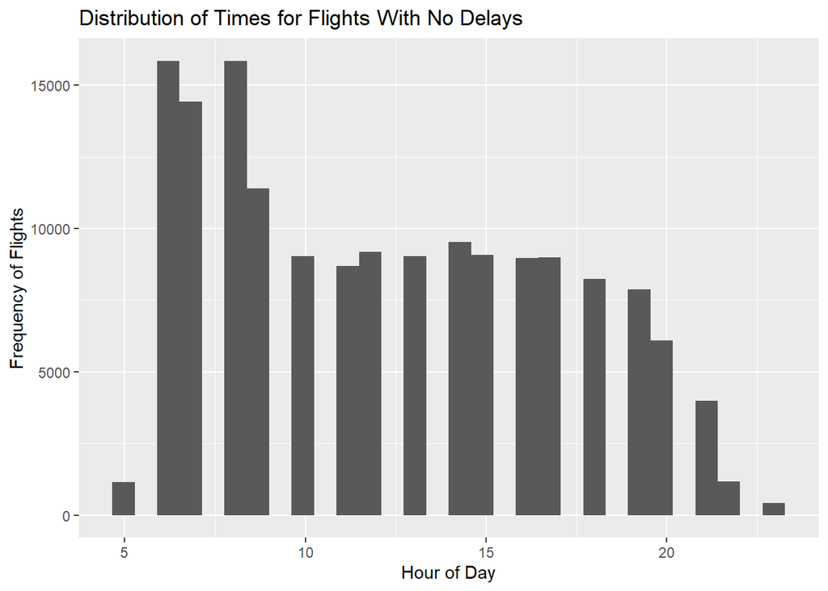

```r
ggplot(timesWithNoDelay, aes(hour, group = time_hour)) + geom_histogram() + labs(x = "Hour of Day", y = "Frequency of Flights", title = "Distribution of Times for Flights With No Delays")
```

4. There are 4 other relational datasets in the nycflights13 package, airlines gives information on the abbreviated airport codes, airports gives info on each airport, identified by the faa airport code, planes gives info on each plane, identified by its tailnum, weather gives info on each NYC airport for each hour.

Loading the datasets…

```r
data(airlines,package='nycflights13')
data(airports,package='nycflights13')
data(planes,package='nycflights13')
data(weather,package='nycflights13')
```

After viewing the diagram, write out how the dataset flights connects to these 4 other datasets (there may be more than one variable that connects them). I’ll do the first one for you:

- flights connects to planes through a single variable, tailnum. Your turn:
- flights connects to airlines through a single variable, carrier.
- flights connects to airports through two variables, origin and dest.
- flights connects to weather through five variables, year, month, day, hour, and origin.
5. The relationship between weather and airports is the single variable origin that they share. On the diagram, an arrow should connect origin in the weather table to faa/origin in the airports table.
6. The following code joins data frames flights and weather together. Based on flight_weather, what weather conditions make it more likely to see a delay?

```r
library(ggplot2)
library(tidyverse)
data(airlines,package='nycflights13')
data(airports,package='nycflights13')
data(planes,package='nycflights13')
data(weather,package='nycflights13')


flight_weather = flights %>%
inner_join(weather, by = c(
  "origin" = "origin",
  "year" = "year",
  "month" = "month",
  "day" = "day",
  "hour" = "hour"
 ))

head(flight_weather)
```

```
## # A tibble: 6 x 29
##    year month   day dep_time sched_dep_time dep_delay arr_time
##   <int> <int> <int>    <int>          <int>     <dbl>    <int>
## 1  2013     1     1      517            515         2      830
## 2  2013     1     1      533            529         4      850
## 3  2013     1     1      542            540         2      923
## 4  2013     1     1      544            545        -1     1004
## 5  2013     1     1      554            600        -6      812
## 6  2013     1     1      554            558        -4      740
## # ... with 22 more variables: sched_arr_time <int>, arr_delay <dbl>,
## #   carrier <chr>, flight <int>, tailnum <chr>, origin <chr>, dest <chr>,
## #   air_time <dbl>, distance <dbl>, hour <dbl>, minute <dbl>,
## #   time_hour.x <dttm>, temp <dbl>, dewp <dbl>, humid <dbl>,
## #   wind_dir <dbl>, wind_speed <dbl>, wind_gust <dbl>, precip <dbl>,
## #   pressure <dbl>, visib <dbl>, time_hour.y <dttm>
```

```r
weatherDelays <- filter(flight_weather, (dep_delay > 60 | arr_delay > 60))

head(weatherDelays)
```

```
## # A tibble: 6 x 29
##    year month   day dep_time sched_dep_time dep_delay arr_time
##   <int> <int> <int>    <int>          <int>     <dbl>    <int>
## 1  2013     1     1      811            630       101     1047
## 2  2013     1     1      826            715        71     1136
## 3  2013     1     1      848           1835       853     1001
## 4  2013     1     1      957            733       144     1056
## 5  2013     1     1     1114            900       134     1447
## 6  2013     1     1     1120            944        96     1331
## # ... with 22 more variables: sched_arr_time <int>, arr_delay <dbl>,
## #   carrier <chr>, flight <int>, tailnum <chr>, origin <chr>, dest <chr>,
## #   air_time <dbl>, distance <dbl>, hour <dbl>, minute <dbl>,
## #   time_hour.x <dttm>, temp <dbl>, dewp <dbl>, humid <dbl>,
## #   wind_dir <dbl>, wind_speed <dbl>, wind_gust <dbl>, precip <dbl>,
## #   pressure <dbl>, visib <dbl>, time_hour.y <dttm>
```

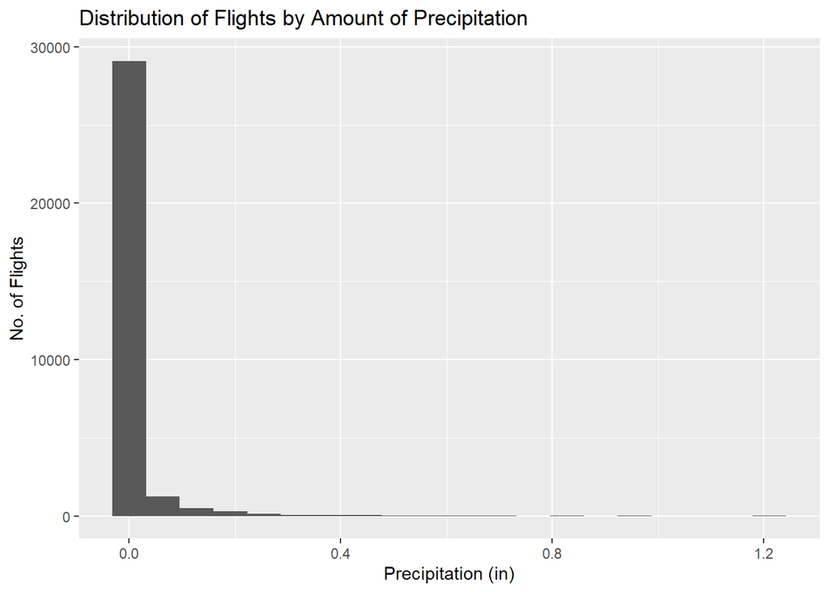

```r
ggplot(weatherDelays, aes(precip)) + geom_histogram(bins=20) + labs(x = "Precipitation (in)", y="No. of Flights", title = "Distribution of Flights by Amount of Precipitation") #distribution of the number of flights versus precipitation amounts
```

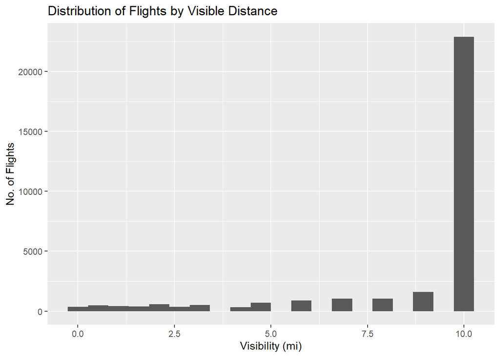

```r
ggplot(weatherDelays, aes(visib)) + geom_histogram(bins=20) + labs(x = "Visibility (mi)", y="No. of Flights", title = "Distribution of Flights by Visible Distance") #distribution of the number of flights versus visiblity
```

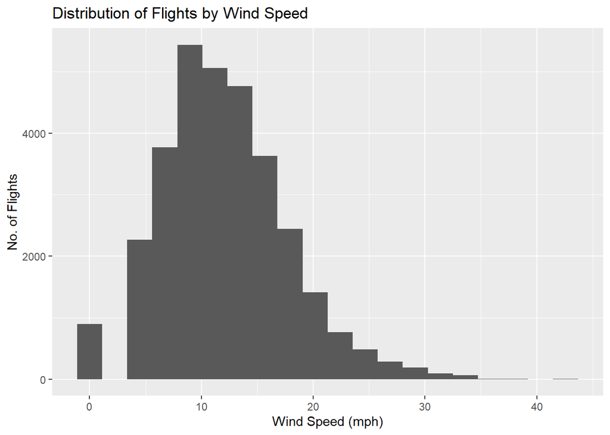

```r
ggplot(weatherDelays, aes(wind_speed)) + geom_histogram(bins=20) + labs(x = "Wind Speed (mph)", y="No. of Flights", title = "Distribution of Flights by Wind Speed") #distribution of the number of flights versus precipitation amounts
```

7. If we had used left_join in the previous problem, would that change our results? Investigate. Does using an inner_join or left_join make more sense here?

```r
library(ggplot2)
library(tidyverse)
data(airlines,package='nycflights13')
data(airports,package='nycflights13')
data(planes,package='nycflights13')
data(weather,package='nycflights13')


flightLeft = flights %>%
left_join(weather, by = c(
  "origin" = "origin",
  "year" = "year",
  "month" = "month",
  "day" = "day",
  "hour" = "hour"
 ))

head(flightLeft)
```

```
## # A tibble: 6 x 29
##    year month   day dep_time sched_dep_time dep_delay arr_time
##   <int> <int> <int>    <int>          <int>     <dbl>    <int>
## 1  2013     1     1      517            515         2      830
## 2  2013     1     1      533            529         4      850
## 3  2013     1     1      542            540         2      923
## 4  2013     1     1      544            545        -1     1004
## 5  2013     1     1      554            600        -6      812
## 6  2013     1     1      554            558        -4      740
## # ... with 22 more variables: sched_arr_time <int>, arr_delay <dbl>,
## #   carrier <chr>, flight <int>, tailnum <chr>, origin <chr>, dest <chr>,
## #   air_time <dbl>, distance <dbl>, hour <dbl>, minute <dbl>,
## #   time_hour.x <dttm>, temp <dbl>, dewp <dbl>, humid <dbl>,
## #   wind_dir <dbl>, wind_speed <dbl>, wind_gust <dbl>, precip <dbl>,
## #   pressure <dbl>, visib <dbl>, time_hour.y <dttm>
```

```r
weatherLeftDelays <- filter(flightLeft, (dep_delay > 60 | arr_delay > 60))

head(weatherLeftDelays)
```

```
## # A tibble: 6 x 29
##    year month   day dep_time sched_dep_time dep_delay arr_time
##   <int> <int> <int>    <int>          <int>     <dbl>    <int>
## 1  2013     1     1      811            630       101     1047
## 2  2013     1     1      826            715        71     1136
## 3  2013     1     1      848           1835       853     1001
## 4  2013     1     1      957            733       144     1056
## 5  2013     1     1     1114            900       134     1447
## 6  2013     1     1     1120            944        96     1331
## # ... with 22 more variables: sched_arr_time <int>, arr_delay <dbl>,
## #   carrier <chr>, flight <int>, tailnum <chr>, origin <chr>, dest <chr>,
## #   air_time <dbl>, distance <dbl>, hour <dbl>, minute <dbl>,
## #   time_hour.x <dttm>, temp <dbl>, dewp <dbl>, humid <dbl>,
## #   wind_dir <dbl>, wind_speed <dbl>, wind_gust <dbl>, precip <dbl>,
## #   pressure <dbl>, visib <dbl>, time_hour.y <dttm>
```

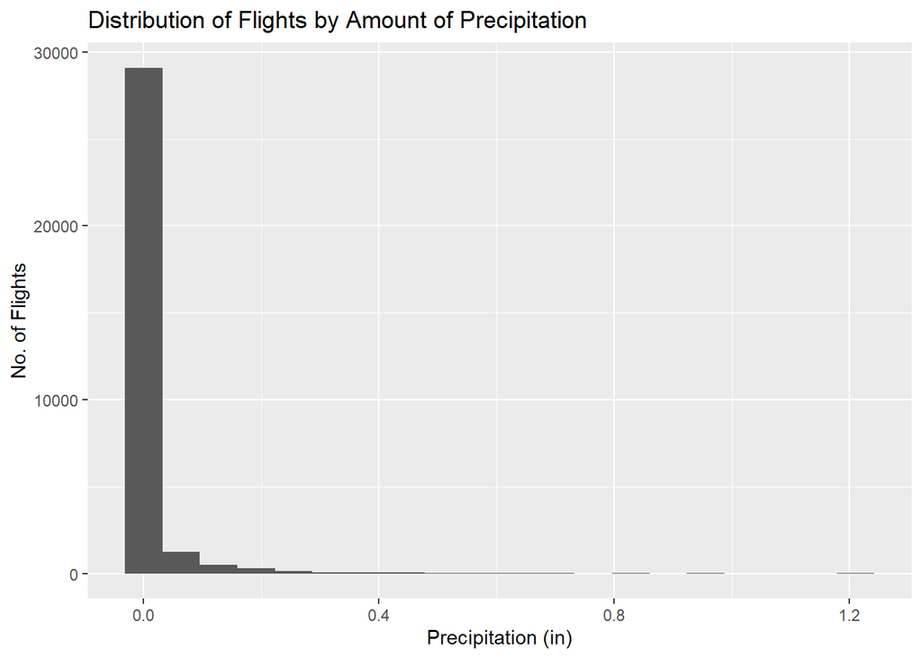

```r
ggplot(weatherLeftDelays, aes(precip)) + geom_histogram(bins=20) + labs(x = "Precipitation (in)", y="No. of Flights", title = "Distribution of Flights by Amount of Precipitation") #distribution of the number of flights versus precipitation amounts
```

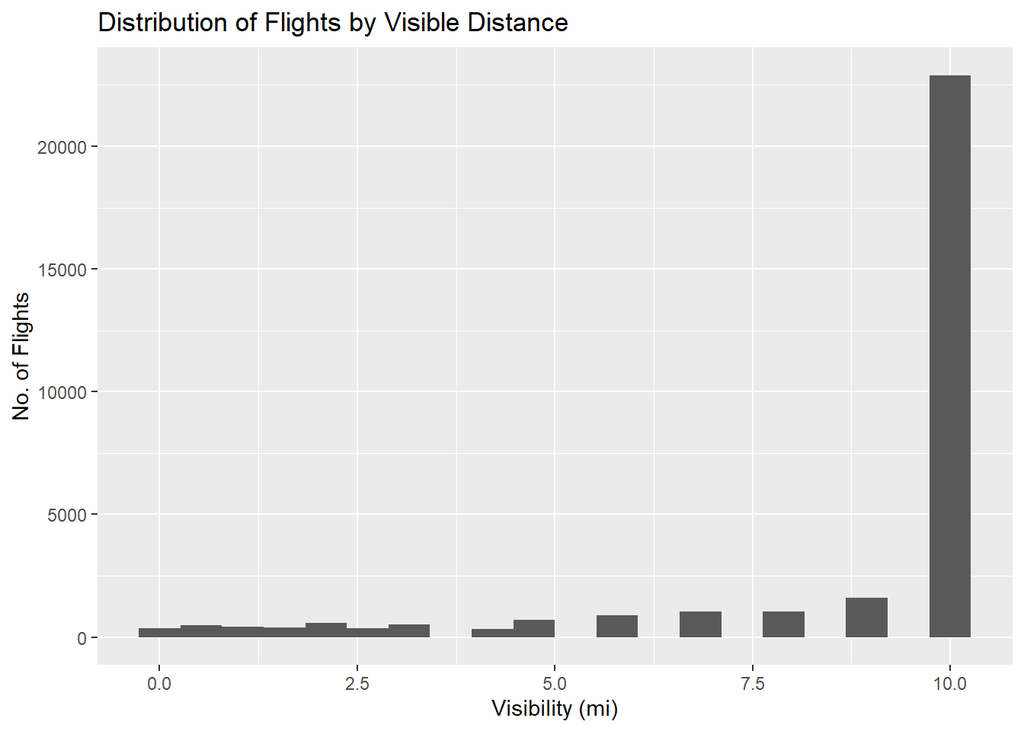

```r
ggplot(weatherLeftDelays, aes(visib)) + geom_histogram(bins=20) + labs(x = "Visibility (mi)", y="No. of Flights", title = "Distribution of Flights by Visible Distance") #distribution of the number of flights versus visiblity
```

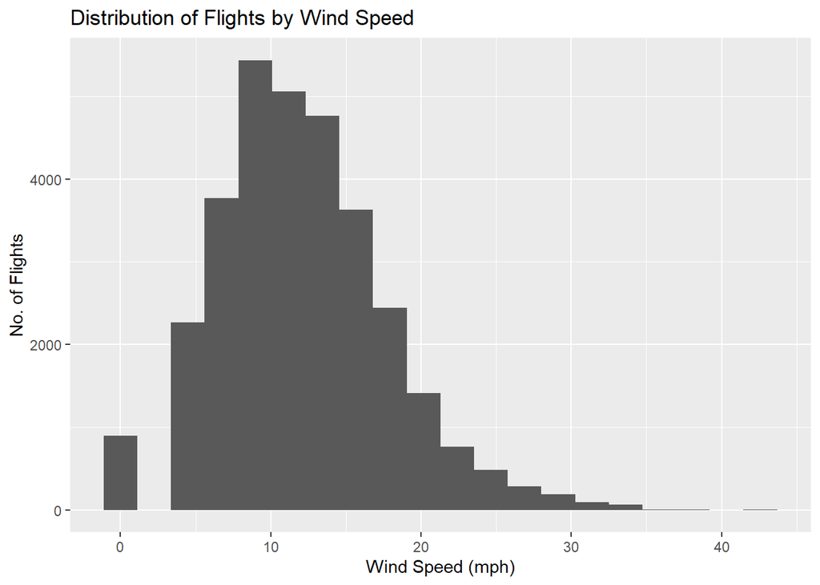

```r
ggplot(weatherLeftDelays, aes(wind_speed)) + geom_histogram(bins=20) + labs(x = "Wind Speed (mph)", y="No. of Flights", title = "Distribution of Flights by Wind Speed") #distribution of the number of flights versus precipitation amounts
```

In a left-join, all data in the left table (in our case, this would be flights) are kept, with nonmatches between the flights and weather tables being filled in by NA values. However, it seems that it doesn’t matter whether we use an inner-join or a left-join, since both combined tables share all of the same attributes/variables. As far as which join makes more sense goes, inner-joins only keep matches between both tables, while all outer-joins, including left-joins, will keep all data in one of the two tables, so I think that when combining tables, you would want to look for matches between the two tables, so I would recommend inner-join over left-join.

8. Is there a relationship between the age of a plane and its departure delays? Information on age of a plane can be found in planes under variable year. Information on departure delays can be found in flights under variable dep_delay.

```r
planes <- mutate(planes, "age" = 2019 - year)

flightsPlanesJoin <-
  planes %>%
  inner_join(flights, by = c("tailnum" = "tailnum"))

head(flightsPlanesJoin)
```

```
## # A tibble: 6 x 28
##   tailnum year.x type  manufacturer model engines seats speed engine   age
##   <chr>    <int> <chr> <chr>        <chr>   <int> <int> <int> <chr>  <dbl>
## 1 N10156    2004 Fixe~ EMBRAER      EMB-~       2    55    NA Turbo~    15
## 2 N10156    2004 Fixe~ EMBRAER      EMB-~       2    55    NA Turbo~    15
## 3 N10156    2004 Fixe~ EMBRAER      EMB-~       2    55    NA Turbo~    15
## 4 N10156    2004 Fixe~ EMBRAER      EMB-~       2    55    NA Turbo~    15
## 5 N10156    2004 Fixe~ EMBRAER      EMB-~       2    55    NA Turbo~    15
## 6 N10156    2004 Fixe~ EMBRAER      EMB-~       2    55    NA Turbo~    15
## # ... with 18 more variables: year.y <int>, month <int>, day <int>,
## #   dep_time <int>, sched_dep_time <int>, dep_delay <dbl>, arr_time <int>,
## #   sched_arr_time <int>, arr_delay <dbl>, carrier <chr>, flight <int>,
## #   origin <chr>, dest <chr>, air_time <dbl>, distance <dbl>, hour <dbl>,
## #   minute <dbl>, time_hour <dttm>
```

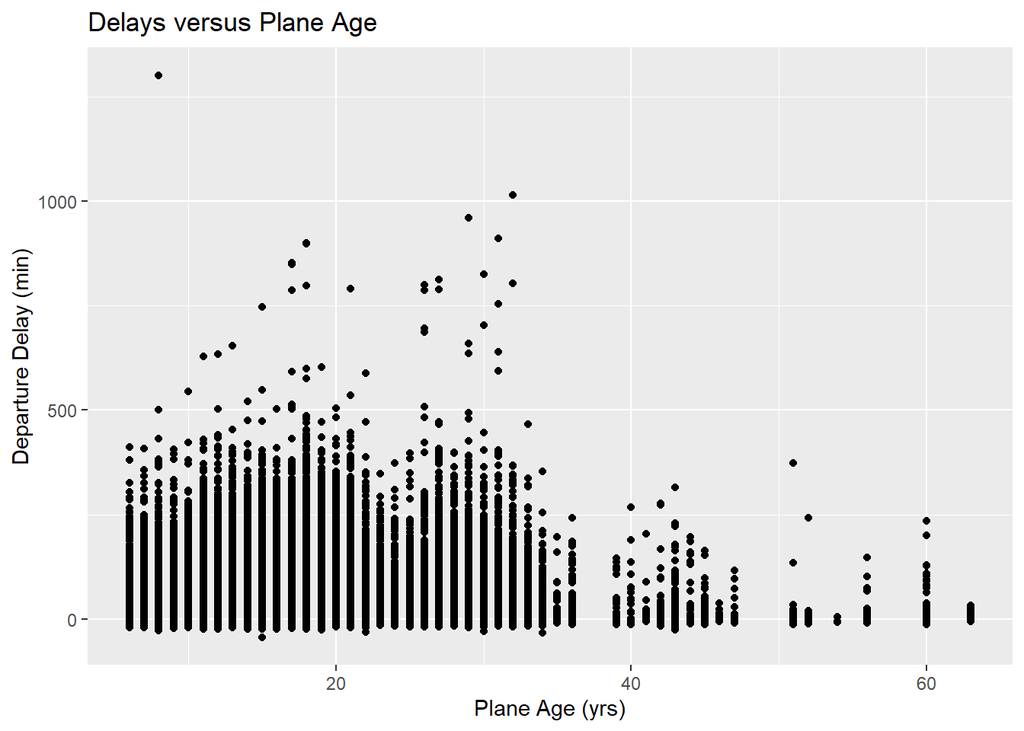

```r
ggplot(flightsPlanesJoin, aes(x = age, y = dep_delay)) + geom_point() + labs(x="Plane Age (yrs)", y = "Departure Delay (min)", title = "Delays versus Plane Age")
```

Judging from the scatter plot made above, there seems to be no correlation between the age of the plane and the length of a delay, in fact older planes seem to have shorter delays than planes age 0-25.

9. What does anti_join(flights, airports, by = c(“dest” = “faa”)) tell you? What does anti_join(airports, flights, by = c(“faa” = “dest”)) tell you?

-Anti-joins between two tables are primarily used to look for join mismatches, since anti_join(x,y) drops all observations in x that have a match in y.

```r
flightsAirports <- inner_join(flights, airports, by = c("dest"="faa"))
flightsAnti <- anti_join(flights, airports, by = c("dest" = "faa"))
head(flightsAirports)
```

```
## # A tibble: 6 x 26
##    year month   day dep_time sched_dep_time dep_delay arr_time
##   <int> <int> <int>    <int>          <int>     <dbl>    <int>
## 1  2013     1     1      517            515         2      830
## 2  2013     1     1      533            529         4      850
## 3  2013     1     1      542            540         2      923
## 4  2013     1     1      554            600        -6      812
## 5  2013     1     1      554            558        -4      740
## 6  2013     1     1      555            600        -5      913
## # ... with 19 more variables: sched_arr_time <int>, arr_delay <dbl>,
## #   carrier <chr>, flight <int>, tailnum <chr>, origin <chr>, dest <chr>,
## #   air_time <dbl>, distance <dbl>, hour <dbl>, minute <dbl>,
## #   time_hour <dttm>, name <chr>, lat <dbl>, lon <dbl>, alt <dbl>,
## #   tz <dbl>, dst <chr>, tzone <chr>
```

```r
head(flightsAnti)
```

```
## # A tibble: 6 x 19
##    year month   day dep_time sched_dep_time dep_delay arr_time
##   <int> <int> <int>    <int>          <int>     <dbl>    <int>
## 1  2013     1     1      544            545        -1     1004
## 2  2013     1     1      615            615         0     1039
## 3  2013     1     1      628            630        -2     1137
## 4  2013     1     1      701            700         1     1123
## 5  2013     1     1      711            715        -4     1151
## 6  2013     1     1      820            820         0     1254
## # ... with 12 more variables: sched_arr_time <int>, arr_delay <dbl>,
## #   carrier <chr>, flight <int>, tailnum <chr>, origin <chr>, dest <chr>,
## #   air_time <dbl>, distance <dbl>, hour <dbl>, minute <dbl>,
## #   time_hour <dttm>
```

```r
head(flights)
```

```
## # A tibble: 6 x 19
##    year month   day dep_time sched_dep_time dep_delay arr_time
##   <int> <int> <int>    <int>          <int>     <dbl>    <int>
## 1  2013     1     1      517            515         2      830
## 2  2013     1     1      533            529         4      850
## 3  2013     1     1      542            540         2      923
## 4  2013     1     1      544            545        -1     1004
## 5  2013     1     1      554            600        -6      812
## 6  2013     1     1      554            558        -4      740
## # ... with 12 more variables: sched_arr_time <int>, arr_delay <dbl>,
## #   carrier <chr>, flight <int>, tailnum <chr>, origin <chr>, dest <chr>,
## #   air_time <dbl>, distance <dbl>, hour <dbl>, minute <dbl>,
## #   time_hour <dttm>
```

```r
flightsAirports2 <- inner_join(airports, flights, by = c("faa"="dest"))
flightsAnti2 <- anti_join(airports, flights, by = c("faa" = "dest"))

head(flightsAirports2)
```

```
## # A tibble: 6 x 26
##   faa   name    lat   lon   alt    tz dst   tzone  year month   day
##   <chr> <chr> <dbl> <dbl> <dbl> <dbl> <chr> <chr> <int> <int> <int>
## 1 ABQ   Albu~  35.0 -107.  5355    -7 A     Amer~  2013    10     1
## 2 ABQ   Albu~  35.0 -107.  5355    -7 A     Amer~  2013    10     2
## 3 ABQ   Albu~  35.0 -107.  5355    -7 A     Amer~  2013    10     3
## 4 ABQ   Albu~  35.0 -107.  5355    -7 A     Amer~  2013    10     4
## 5 ABQ   Albu~  35.0 -107.  5355    -7 A     Amer~  2013    10     5
## 6 ABQ   Albu~  35.0 -107.  5355    -7 A     Amer~  2013    10     6
## # ... with 15 more variables: dep_time <int>, sched_dep_time <int>,
## #   dep_delay <dbl>, arr_time <int>, sched_arr_time <int>,
## #   arr_delay <dbl>, carrier <chr>, flight <int>, tailnum <chr>,
## #   origin <chr>, air_time <dbl>, distance <dbl>, hour <dbl>,
## #   minute <dbl>, time_hour <dttm>
```

```r
head(flightsAnti2)
```

```
## # A tibble: 6 x 8
##   faa   name                       lat   lon   alt    tz dst   tzone
##   <chr> <chr>                    <dbl> <dbl> <dbl> <dbl> <chr> <chr>
## 1 04G   Lansdowne Airport         41.1 -80.6  1044    -5 A     America/New~
## 2 06A   Moton Field Municipal A~  32.5 -85.7   264    -6 A     America/Chi~
## 3 06C   Schaumburg Regional       42.0 -88.1   801    -6 A     America/Chi~
## 4 06N   Randall Airport           41.4 -74.4   523    -5 A     America/New~
## 5 09J   Jekyll Island Airport     31.1 -81.4    11    -5 A     America/New~
## 6 0A9   Elizabethton Municipal ~  36.4 -82.2  1593    -5 A     America/New~
```

```r
head(flights)
```

```
## # A tibble: 6 x 19
##    year month   day dep_time sched_dep_time dep_delay arr_time
##   <int> <int> <int>    <int>          <int>     <dbl>    <int>
## 1  2013     1     1      517            515         2      830
## 2  2013     1     1      533            529         4      850
## 3  2013     1     1      542            540         2      923
## 4  2013     1     1      544            545        -1     1004
## 5  2013     1     1      554            600        -6      812
## 6  2013     1     1      554            558        -4      740
## # ... with 12 more variables: sched_arr_time <int>, arr_delay <dbl>,
## #   carrier <chr>, flight <int>, tailnum <chr>, origin <chr>, dest <chr>,
## #   air_time <dbl>, distance <dbl>, hour <dbl>, minute <dbl>,
## #   time_hour <dttm>
```

Anti-joining between airports and flights, this time switching the order of the join so we also have to switch the order of the column names that correspond to the correct tables, shows me only columns found in the airports table. This further shows that airports and flights don’t have any other corresponding columns/values, aside from the primary key that they share (faa and dest)